# ds202_hw5

YangfanCai/yangfanc

3/31/2020

# 1.The complete dataset is too large. Download and import the alcohol sales data for Ames only:

a.Go to https://data.iowa.gov/Sales-Distribution/2019-Iowa-Liquor-Sales/38x4-vs5h b.Click Filter – Filter – Go advanced now c.Add a New Filter Condition: City is Ames. d.Export – CSV – Download e.Use readr::read_csv to import.

```r
library(dplyr)
```

```r
library(ggplot2)
library(lubridate)
library(tidyverse)
if (!require("tidyverse")) {
install.packages("tidyverse")
}
if (!require("dplyr")) {
install.packages("dplyr")
}
if (!require("ggplot2")) {
install.packages("ggplot2")
}
if (!require("readr")) {
install.packages("readr")
}
if (!require("lubridate")) {
install.packages("lubridate")
}
```

```r
ames <- readr::read_csv('~/Downloads/2019_Iowa_Liquor_Sales.csv')
```

# 2.Data cleaning:

1. extract geographic latitude and longitude from the variable Store Location
2. make sure the variables are in the correct type, by converting incorrect variable types.
3. extract year, month and day from the variable Date as separate columns.

```r
#a
amescleana <- ames %>%
  separate('Store Location', c("Address", "City", "Coordinates"), sep = "\n") %>%
  mutate(Coordinates = gsub("[()]", "", Coordinates)) %>%
  separate("Coordinates", c("Latitude", "Longitude"), sep = ",")
amescleana
```

```
## # A tibble: 63,103 x 25
##    `Invoice/Item N… Date  `Store Number` `Store Name` `Zip Code` `County Number`
##    <chr>            <chr>          <dbl> <chr>             <dbl>           <dbl>
##  1 INV-16712000040  01/0…           2500 Hy-Vee Food…      50010              85
##  2 INV-16712000012  01/0…           2500 Hy-Vee Food…      50010              85
##  3 INV-16712000070  01/0…           2500 Hy-Vee Food…      50010              85
##  4 INV-16712000009  01/0…           2500 Hy-Vee Food…      50010              85
##  5 INV-16712000160  01/0…           2500 Hy-Vee Food…      50010              85
##  6 INV-16712000119  01/0…           2500 Hy-Vee Food…      50010              85
##  7 INV-16712000153  01/0…           2500 Hy-Vee Food…      50010              85
##  8 INV-16712000114  01/0…           2500 Hy-Vee Food…      50010              85
##  9 INV-16834400018  01/0…           4251 AJ's Liquor…      50014              85
## 10 INV-16834600031  01/0…           2500 Hy-Vee Food…      50010              85
## # … with 63,093 more rows, and 19 more variables: County <chr>, Address <chr>,
## #   City <chr>, Latitude <chr>, Longitude <chr>, Category <dbl>, `Category
## #   Name` <chr>, `Vendor Number` <chr>, `Vendor Name` <chr>, `Item
## #   Number` <dbl>, `Item Description` <chr>, Pack <dbl>, `Bottle Volume
## #   (ml)` <dbl>, `State Bottle Cost` <dbl>, `State Bottle Retail` <dbl>,
## #   `Bottles Sold` <dbl>, `Sale (Dollars)` <dbl>, `Volume Sold (Liters)` <dbl>,
## #   `Volume Sold (Gallons)` <dbl>
```

```r
amesclean1 <- ames %>%
  separate(`Store Location`, c('Point', 'long', 'lat'), sep=' ') %>%
  separate(long, c('extra', 'long'), sep = '\\(') %>%
  separate(lat, c('lat', 'extra2'), sep = '\\)') %>%
  select(-extra, -extra2, -Point)
amesclean1
```

```
## # A tibble: 63,103 x 25
##    `Invoice/Item N… Date  `Store Number` `Store Name` Address City  `Zip Code`
##    <chr>            <chr>          <dbl> <chr>        <chr>   <chr>      <dbl>
##  1 INV-16712000040  01/0…           2500 Hy-Vee Food… 3800 W… Ames       50010
##  2 INV-16712000012  01/0…           2500 Hy-Vee Food… 3800 W… Ames       50010
##  3 INV-16712000070  01/0…           2500 Hy-Vee Food… 3800 W… Ames       50010
##  4 INV-16712000009  01/0…           2500 Hy-Vee Food… 3800 W… Ames       50010
##  5 INV-16712000160  01/0…           2500 Hy-Vee Food… 3800 W… Ames       50010
##  6 INV-16712000119  01/0…           2500 Hy-Vee Food… 3800 W… Ames       50010
##  7 INV-16712000153  01/0…           2500 Hy-Vee Food… 3800 W… Ames       50010
##  8 INV-16712000114  01/0…           2500 Hy-Vee Food… 3800 W… Ames       50010
##  9 INV-16834400018  01/0…           4251 AJ's Liquor… 4518 M… Ames       50014
## 10 INV-16834600031  01/0…           2500 Hy-Vee Food… 3800 W… Ames       50010
## # … with 63,093 more rows, and 18 more variables: long <chr>, lat <chr>,
## #   `County Number` <dbl>, County <chr>, Category <dbl>, `Category Name` <chr>,
## #   `Vendor Number` <chr>, `Vendor Name` <chr>, `Item Number` <dbl>, `Item
## #   Description` <chr>, Pack <dbl>, `Bottle Volume (ml)` <dbl>, `State Bottle
## #   Cost` <dbl>, `State Bottle Retail` <dbl>, `Bottles Sold` <dbl>, `Sale
## #   (Dollars)` <dbl>, `Volume Sold (Liters)` <dbl>, `Volume Sold
## #   (Gallons)` <dbl>
```

```r
#b
amesb <- ames %>%
  separate(`Store Location`, c('Point', 'long', 'lat'), sep=' ') %>%
  separate(long, c('extra', 'long'), sep = '\\(') %>%
  separate(lat, c('lat', 'extra2'), sep = '\\)') %>%
  select(-extra, -extra2, -Point)
amesb
```

```
## # A tibble: 63,103 x 25
##    `Invoice/Item N… Date  `Store Number` `Store Name` Address City  `Zip Code`
##    <chr>            <chr>          <dbl> <chr>        <chr>   <chr>      <dbl>
##  1 INV-16712000040  01/0…           2500 Hy-Vee Food… 3800 W… Ames       50010
##  2 INV-16712000012  01/0…           2500 Hy-Vee Food… 3800 W… Ames       50010
##  3 INV-16712000070  01/0…           2500 Hy-Vee Food… 3800 W… Ames       50010
##  4 INV-16712000009  01/0…           2500 Hy-Vee Food… 3800 W… Ames       50010
##  5 INV-16712000160  01/0…           2500 Hy-Vee Food… 3800 W… Ames       50010
##  6 INV-16712000119  01/0…           2500 Hy-Vee Food… 3800 W… Ames       50010
##  7 INV-16712000153  01/0…           2500 Hy-Vee Food… 3800 W… Ames       50010
##  8 INV-16712000114  01/0…           2500 Hy-Vee Food… 3800 W… Ames       50010
##  9 INV-16834400018  01/0…           4251 AJ's Liquor… 4518 M… Ames       50014
## 10 INV-16834600031  01/0…           2500 Hy-Vee Food… 3800 W… Ames       50010
## # … with 63,093 more rows, and 18 more variables: long <chr>, lat <chr>,
## #   `County Number` <dbl>, County <chr>, Category <dbl>, `Category Name` <chr>,
## #   `Vendor Number` <chr>, `Vendor Name` <chr>, `Item Number` <dbl>, `Item
## #   Description` <chr>, Pack <dbl>, `Bottle Volume (ml)` <dbl>, `State Bottle
## #   Cost` <dbl>, `State Bottle Retail` <dbl>, `Bottles Sold` <dbl>, `Sale
## #   (Dollars)` <dbl>, `Volume Sold (Liters)` <dbl>, `Volume Sold
## #   (Gallons)` <dbl>
```

```r
ames2 <- amesclean1 %>%
  mutate(long = as.numeric(long),
         lat = as.numeric(lat))
ames2
```

```
## # A tibble: 63,103 x 25
##    `Invoice/Item N… Date  `Store Number` `Store Name` Address City  `Zip Code`
##    <chr>            <chr>          <dbl> <chr>        <chr>   <chr>      <dbl>
##  1 INV-16712000040  01/0…           2500 Hy-Vee Food… 3800 W… Ames       50010
##  2 INV-16712000012  01/0…           2500 Hy-Vee Food… 3800 W… Ames       50010
##  3 INV-16712000070  01/0…           2500 Hy-Vee Food… 3800 W… Ames       50010
##  4 INV-16712000009  01/0…           2500 Hy-Vee Food… 3800 W… Ames       50010
##  5 INV-16712000160  01/0…           2500 Hy-Vee Food… 3800 W… Ames       50010
##  6 INV-16712000119  01/0…           2500 Hy-Vee Food… 3800 W… Ames       50010
##  7 INV-16712000153  01/0…           2500 Hy-Vee Food… 3800 W… Ames       50010
##  8 INV-16712000114  01/0…           2500 Hy-Vee Food… 3800 W… Ames       50010
##  9 INV-16834400018  01/0…           4251 AJ's Liquor… 4518 M… Ames       50014
## 10 INV-16834600031  01/0…           2500 Hy-Vee Food… 3800 W… Ames       50010
## # … with 63,093 more rows, and 18 more variables: long <dbl>, lat <dbl>,
## #   `County Number` <dbl>, County <chr>, Category <dbl>, `Category Name` <chr>,
## #   `Vendor Number` <chr>, `Vendor Name` <chr>, `Item Number` <dbl>, `Item
## #   Description` <chr>, Pack <dbl>, `Bottle Volume (ml)` <dbl>, `State Bottle
## #   Cost` <dbl>, `State Bottle Retail` <dbl>, `Bottles Sold` <dbl>, `Sale
## #   (Dollars)` <dbl>, `Volume Sold (Liters)` <dbl>, `Volume Sold
## #   (Gallons)` <dbl>
```

```r
#c
ames3 <- ames2 %>%
  separate(Date, into = c('Month','Day','Year'), sep = '/') %>%
  mutate(Month = as.integer(Month),
         Day = as.integer(Day),
         Year = as.integer(Year))
ames3
```

```
## # A tibble: 63,103 x 27
##    `Invoice/Item N… Month   Day  Year `Store Number` `Store Name` Address City
##    <chr>            <int> <int> <int>          <dbl> <chr>        <chr>   <chr>
##  1 INV-16712000040      1     3  2019           2500 Hy-Vee Food… 3800 W… Ames
##  2 INV-16712000012      1     3  2019           2500 Hy-Vee Food… 3800 W… Ames
##  3 INV-16712000070      1     3  2019           2500 Hy-Vee Food… 3800 W… Ames
##  4 INV-16712000009      1     3  2019           2500 Hy-Vee Food… 3800 W… Ames
##  5 INV-16712000160      1     3  2019           2500 Hy-Vee Food… 3800 W… Ames
##  6 INV-16712000119      1     3  2019           2500 Hy-Vee Food… 3800 W… Ames
##  7 INV-16712000153      1     3  2019           2500 Hy-Vee Food… 3800 W… Ames
##  8 INV-16712000114      1     3  2019           2500 Hy-Vee Food… 3800 W… Ames
##  9 INV-16834400018      1     9  2019           4251 AJ's Liquor… 4518 M… Ames
## 10 INV-16834600031      1     9  2019           2500 Hy-Vee Food… 3800 W… Ames
## # … with 63,093 more rows, and 19 more variables: `Zip Code` <dbl>, long <dbl>,
## #   lat <dbl>, `County Number` <dbl>, County <chr>, Category <dbl>, `Category
## #   Name` <chr>, `Vendor Number` <chr>, `Vendor Name` <chr>, `Item
## #   Number` <dbl>, `Item Description` <chr>, Pack <dbl>, `Bottle Volume
## #   (ml)` <dbl>, `State Bottle Cost` <dbl>, `State Bottle Retail` <dbl>,
## #   `Bottles Sold` <dbl>, `Sale (Dollars)` <dbl>, `Volume Sold (Liters)` <dbl>,
## #   `Volume Sold (Gallons)` <dbl>
```

# 3.First overview:

a.Plot a scatterplot of lat and long of store locations.

b.Provide a visual breakdown of the liquor category (by Category Name). Include volume sold in the breakdown.

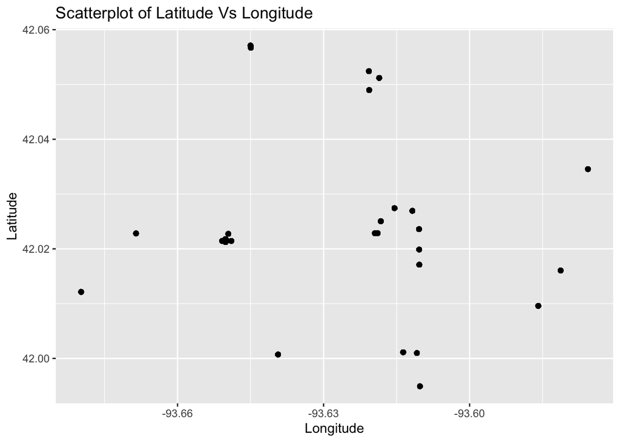

```r
#a
ames3 %>% ggplot(aes(x = long, y = lat))+
  geom_point(na.rm = TRUE) + geom_jitter(na.rm = TRUE)+
  ggtitle("Scatterplot of Latitude Vs Longitude")+ xlab("Longitude")+ ylab("Latitude")
```

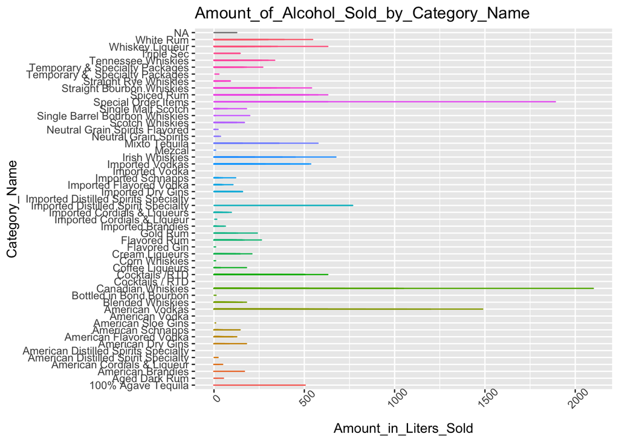

```r
#b
ames3 %>% ggplot(aes(x = `Category Name`, y = `Volume Sold (Liters)`))+
  geom_line(aes(color = `Category Name`))+ theme(legend.position = "none", axis.text.x = element_text(angle = 45))+ coord_flip()+
  ggtitle("Amount_of_Alcohol_Sold_by_Category_Name")+ xlab("Category_Name")+ ylab("Amount_in_Liters_Sold")
```